# Reducer notes

Alexander D’Amour and Alexander Franks

# Setup and Motivation

## Causal effect estimation and overlap

Consider an observational study where we model the data as iid triples $((Y(0), Y(1)), T, X) \sim P$ of potential outcomes, treatment, and covariates, drawn from some superpopulation with distribution $P$. Let $P_0(X) := P(X \mid T = 0)$ and $P_1(X) = P(X \mid T = 1)$. Let $e(X) = P(T = 1 \mid X)$. Identifcation of the ATE of $T$
$$\tau^{ATE} := E_P[Y(1) - Y(0)]$$
depends on two key assumptions.
$$\begin{align}
(Y(0), Y(1)) \perp T \mid X \quad \text{and} \quad 0 < e(X) < 1.
\end{align}$$
These are the **unconfoundedness** and **overlap** conditions, respectively. Under these assumptions, $\tau^{ATE}$ is identified by the observable functional
$$\tau^{ATE} = E_P[E_P[Y^{obs} \mid X, T = 1] - E_P[Y^{obs} | X, T = 0]].$$
To make uniform inferential guarantees about estimates of $\tau^{ATE}$, it is common to require that $e(X)$ be bounded away from 0 and 1 by some constant $\eta \in (0, 1/2)$:
$$\eta < e(X) < 1-\eta.$$
In many cases, particularly when $X$ is high-dimensional, this assumption may not hold for a particular data-generating process $P$.

This motivates finding a reduction of $X$, $d(X)$, such that overlap holds in the reduction $d(X)$:
$$\eta < e_d(X) := P(T = 1 \mid ) < 1-\eta.$$
If $d(X)$ satisfies this condition, the following functional is identified:
$$\tau^{ATE}_d = E_P[E_P[Y^{obs} \mid d(X), T = 1] - E_P[Y^{obs} \mid d(X), T = 0]].$$

The bias induced by conditioning on $d(X)$ instead of $X$ is
$$\tau^{ATE} - \tau_d^{ATE} = E_P\left[\frac{Cov(Y(1), X \mid d(X))}{e(X)} + \frac{Cov(Y(0), X \mid d(X))}{1-e(X)} \right].$$

Ideally, we would search for a reduction $d(X)$ that induces no bias. One sufficient condition is that:
$$Cov(Y(t), T \mid d(X)) = 0 \quad \text{for } t = 0, 1, \text{ w.p. 1}.$$

Note that, under unconfoundedness, $Cov(Y(t), T \mid X) = 0$ for all $X$. Letting $m_t(X) := E[Y(t) \mid X]$,
$$\begin{align}
Cov(Y(t), T \mid d(X)) &= E[ Cov(Y(t), T \mid X) \mid d(X) ] + Cov( E[Y(t) \mid X], E[T \mid X] \mid d(X) )\\
&= Cov( m_t(X), e(X) \mid d(X)).
\end{align}$$

Thus, a sufficient condition for unbiasedness is that $d(X)$ satisfies
$$Cov(m_t(X), e(X) \mid d(X)) = 0 \quad \text{for } t = 0, \text{ w.p. }1.$$

The goal of the reducer is to take an outcome model $m_0(x)$ and a treatment model $e(X)$ and to identify a function $d(X)$ conditional on which the two are orthogonal.

**Remark**: We could also balance bias and variance, by considering the semiparametric efficiency bound:
$$V^{eff} = E_P\left[\frac{Var(Y(1) \mid d(X))}{e_d(X)}
+ \frac{Var(Y(0) \mid d(X))}{1-e_d(X)} + (\tau_d(X) - \tau^{ATE})^2\right],$$
where $\tau_d(X)$ is the conditional average treatment effect given $d(X)$, $E[Y(1) - Y(0) \mid d(X)]$.

# SNoTE

Consider both linear mean and propensity models. Assume that $r(X)$ is also linear in $X$.
$$\begin{align}
m_0(X) &= \mathbf{\alpha}'X \quad \text{(Expectation of control outcome)}\\
e(X) &= \mathbf{\beta}'X \quad \text{(Propensity score)}\\
d(X) &= \gamma'X \quad \text{(Deconfounding score)}
\end{align}$$
where $\alpha$ is an $p \times m_\alpha$ matrix and $\beta$ is a $p \times m_\beta$ matrix with $m < p$. Assume (welog?) that $\alpha$ and $\beta$ are semi-orthogonal matrices, e.g. $\alpha^T\alpha = I$.

### Partial Correlation Condition

$$\begin{align}
\Sigma_{XX} &= Cov(X)\\
\Lambda &= (\alpha \beta \gamma)' \Sigma_{XX} (\alpha \beta \gamma)\\
\Lambda_{YT|R} &= \Lambda_{YT} - \Lambda_{YT;R} \Lambda_{RR}^{-1} \Lambda_{R;YT}\\
& = \left( \begin{array}{rr} \alpha' \Sigma \alpha&\alpha'\Sigma\beta\\
\beta' \Sigma \alpha&\beta'\Sigma\beta
\end{array}
\right) - \frac{1}{\gamma' \Sigma \gamma}
\left(
\begin{array}{r} \alpha' \Sigma \gamma\\
\beta' \Sigma \gamma
\end{array}\right)
\left(
\begin{array}{r} \alpha' \Sigma \gamma\\
\beta' \Sigma \gamma
\end{array}\right)'
\end{align}$$

Condition is
$$\begin{align}
\alpha' \Sigma \beta &= (\alpha' \Sigma \gamma) (\gamma' \Sigma \gamma)^{-1} (\gamma' \Sigma \beta)\\
\end{align}$$
which implies that
$$\alpha' (\Sigma - \Sigma\gamma (\gamma' \Sigma \gamma)^{-1}\gamma'\Sigma)\beta = 0$$

### Special Case: $X$ has identity covariance, $X \in \mathbb R^3$

Special case $\Sigma = I$; $\alpha, \beta, \gamma$ all vectors in $\mathbb R^3$.
$$(\gamma'\gamma)(\alpha'\beta) = (\gamma'\alpha)(\beta'\gamma)\quad \Rightarrow \quad
\gamma' (I \alpha'\beta - \alpha\beta') \gamma = 0$$

**Interpretation of condition**: If $\gamma$, $\alpha$, $\beta$ are all normalized, says that correlation between $\alpha$ and $\beta$ must be smaller than correlation between $\gamma$ and $\alpha$ and $\gamma$ and $\beta$. In particular $\alpha$ is $\gamma$ that is the least correlated with $\beta$. As a result, we have the following conjecture.

**Conjecture**: The prognostic score is the overlap maximizing deconfounding score.

This defines a quadric surface of solutions $\gamma$. We can characterize the surface in terms of the eigenvalues of the symmetrized matrix $A$ defined as:
$$\begin{align}
\tilde A &= I\alpha'\beta - \alpha \beta'\\
A &= \frac{1}{2}(\tilde A + \tilde A')
\end{align}$$
Note that $\gamma' \tilde A \gamma = 0$ implies $\gamma' A \gamma = 0$. If $A$ has two positive eigenvalues and one negative eigenvalue, then the surface of solutions is a cone.

**Conjecture**: $\gamma = \alpha$ and $\gamma = \beta$ are also clearly solutions. Thus, the surface should always contain $\alpha$ and $\beta$.

Code to construct and characterize matrix $A$:

```r
diagnostic <- FALSE
alpha <- c(1, -1, 0)
beta <- c(1, 0, 1)

redA <- function(alpha, beta){
  Atilde <- diag(sum(alpha*beta), length(alpha)) - (alpha %*% t(beta))
  A <- (Atilde + t(Atilde))/2
}
A <- redA(alpha, beta)
eigs <- eigen(A)
if(diagnostic){
  print(A)
  print(eigs)
}

cone_params <- eigs$values
S <- rotation <- eigs$vectors
```

Strategy to find solutions $\gamma$. In rotated coordinates $x$, $y$, $z$, with $z$ set to the coordinate with negative eigenvalue, WLOG, fix $z = |\lambda_3|^{-1/2}$ and characterize resulting ellipse given by:
$$\lambda_1 x^2 + \lambda_2 y^2 = 1$$
We can now parameterize the solutions for $\gamma$ in terms of $t$:
$$\gamma(t) = S\left( \begin{array}{c} x(t)\\y(t)\\z(t) \end{array}\right)
= S\left( \begin{array}{c}\lambda_1^{-1/2} \cos(t)\\\lambda_2^{-1/2} \sin(t)\\|\lambda_3|^{-1/2} \end{array}\right)$$
Where $S'$ is the transpose of the matrix of eigenvectors of $A$.

```r
gamma_sol <- function(t, cone_params, S){
  S %*% c(cone_params[1]^(-1/2) * cos(t),
          cone_params[2]^(-1/2) * sin(t),
          abs(cone_params[3])^(-1/2))
}

vnorm <- function(v){
  sqrt(sum(v^2))
}

g1 <- gamma_sol(3*pi/2, cone_params, S)
g2 <- gamma_sol(pi/2, cone_params, S)
g3 <- gamma_sol(pi/3, cone_params, S)
```

Testing:

```
## [1] "thing: 1.732051"  "thing: -0.000000" "thing: 0.000000"
##           [,1]
## [1,] 0.7069159
##           [,1]
## [1,] 0.7093705
```

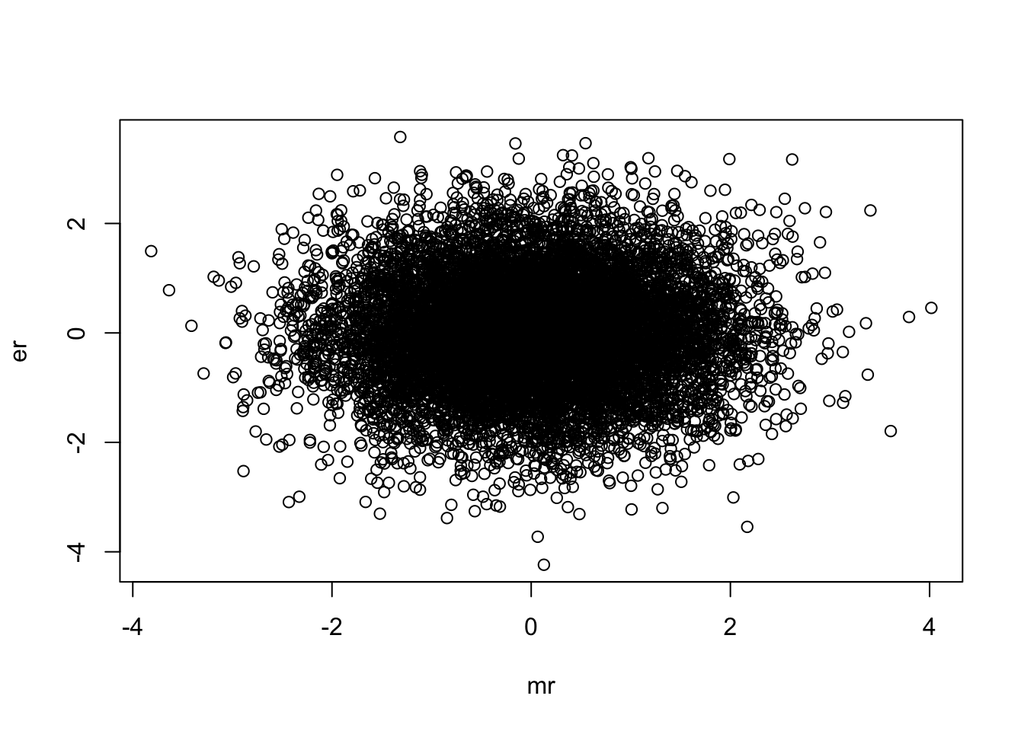

```
## [1] 0.01319618
## [1] "thing: 0.577350"  "thing: -1.154701" "thing: 1.154701"
##          [,1]
## [1,] 0.711035
##           [,1]
## [1,] 0.7107433
```

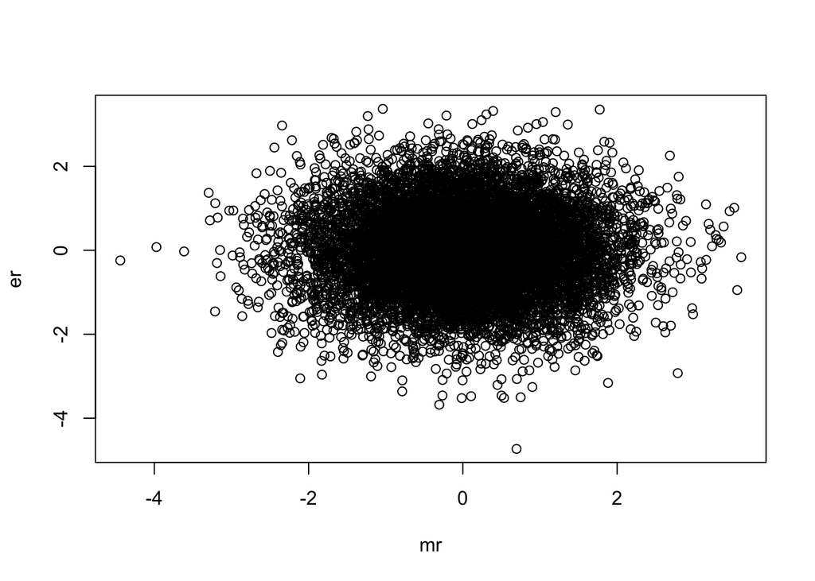

```
## [1] 0.00541947
## [1] "thing: 0.654701"  "thing: -0.788675" "thing: 1.366025"
##           [,1]
## [1,] 0.6044398
##          [,1]
## [1,] 0.838187
```

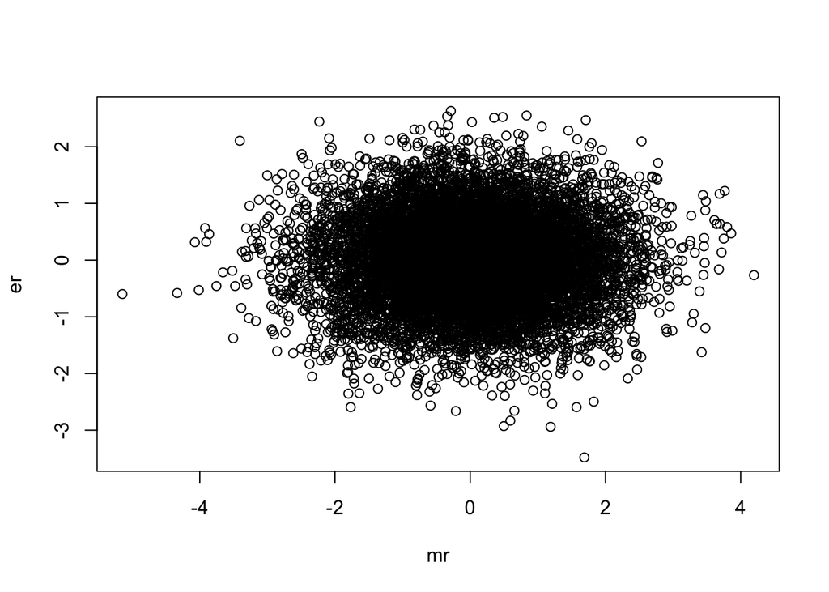

```
## [1] 0.003246261
```

```r
library(mvtnorm)
X <- rmvnorm(1e4, rep(0, 3), diag(1, 3))
m <- X %*% alpha
e <- X %*% beta

for(g in list(g1, g2, g3)){
  s1 <- X %*% g
  print(sprintf("thing: %f", g))
  print(cor(m, s1))
  print(cor(e, s1))
  mr <- lm(m ~ s1-1)$residuals
  er <- lm(e ~ s1-1)$residuals
  plot(mr, er)
  print(cor(mr, er))
}
```

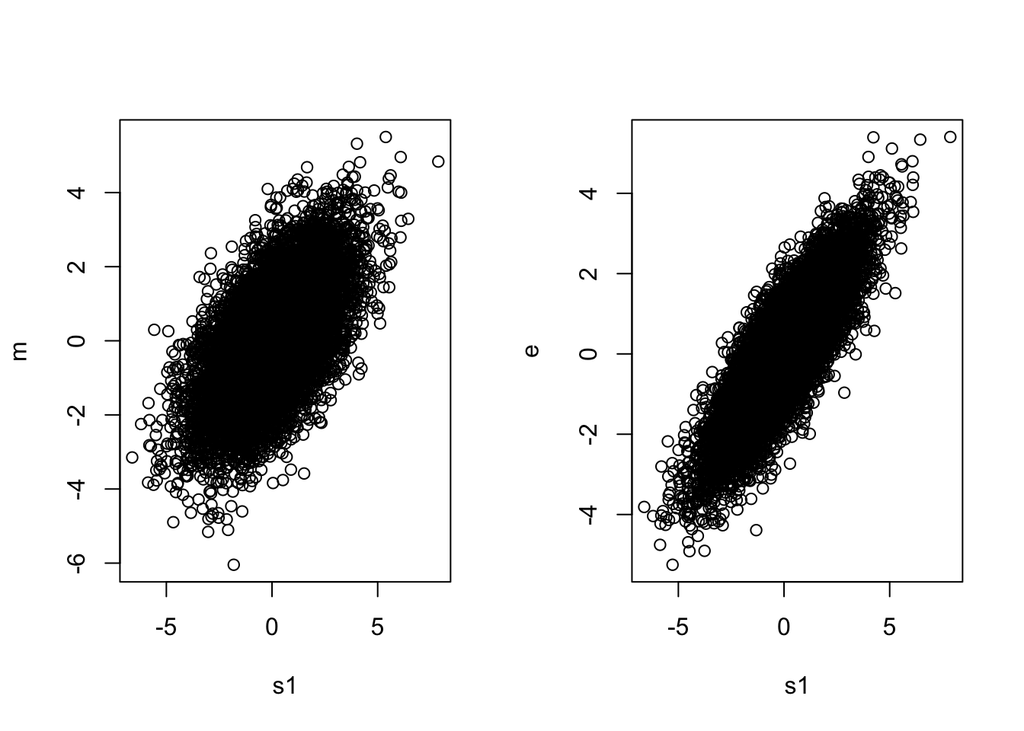

```r
par(mfrow=c(1,2))
plot(s1, m)
plot(s1, e)
```

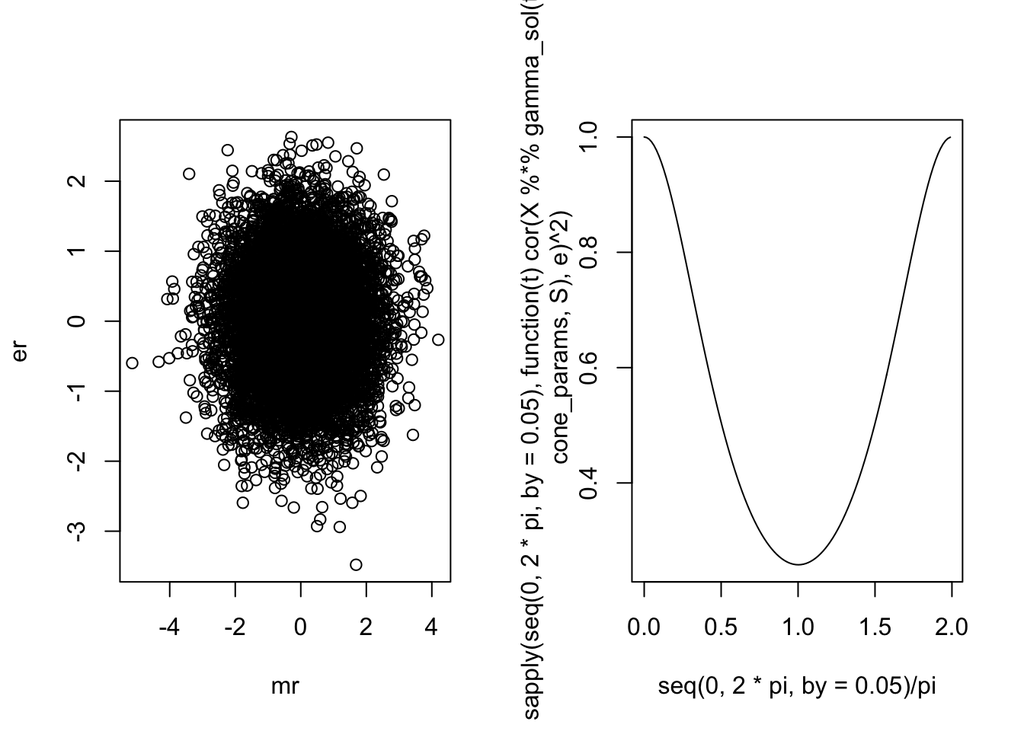

```r
mr <- lm(m ~ s1-1)$residuals
er <- lm(e ~ s1-1)$residuals
plot(mr, er)

plot(seq(0, 2*pi, by=.05)/pi, sapply(seq(0, 2*pi, by=.05), function(t) cor(X %*% gamma_sol(t, cone_params, S), e)^2), type='l')
```

```r
that <- optimize(function(t) cor(X %*% gamma_sol(t, cone_params, S), e)^2,
                             c(0, 2*pi))$minimum
ghat <- gamma_sol(that, cone_params, S)
shat <- X %*% ghat
print(that/pi)
```

```
## [1] 1.001876
```

```r
print(cor(m,e))
```

```
##          [,1]
## [1,] 0.508044
```

```r
print(cor(shat,e))
```

```
##           [,1]
## [1,] 0.5080409
```

```r
print(cor(shat,m))
```

```
##           [,1]
## [1,] 0.9999935
```

### General solution space for $\gamma$

Assume welog that $\Sigma = I$ and $\gamma$, $\alpha$ and $\beta$ are semi-orthogonal matrices. Then the above condition is equivalent to
$$\alpha'(I - \gamma\gamma^T)\beta = 0$$

Let $M = (I - \gamma\gamma^T)$. Then $\alpha M\beta' = 0$ implies that $\alpha M$ is in the null space of $\beta$ **or** $M\beta'$ is in the nullspace of $\alpha$. For a $k$-dimensional reducer $\gamma$, this implies that $M$ is a rank ($p - k$) projection matrix into a subspace of the null spaces of $\alpha$ and/or $\beta$.

```r
p <- 5
alpha <- c(1, -1, 0, rep(0, p-3))/sqrt(2)
beta <- c(1, 0, 1, rep(0, p-3))/sqrt(2)

library(mvtnorm)
library(rstiefel)

X <- rmvnorm(1e4, rep(0, p), diag(1, p))
m <- X %*% alpha
e <- X %*% beta

## projection matrices into the nullspaces of alpha and beta
A <- diag(p) - alpha %*% t(alpha)
B <- diag(p) - beta %*% t(beta)

# choose a random plane in the nullspace of alpha
mixer <- rustiefel(p-1, 2)
z <- eigen(A)$vectors[, 1:(p-1)] %*% mixer

# choose the direction in the nullspace of beta orthogonal
# To z
w <- eigen(B %*% (diag(p) - z %*% t(z)))$vectors[, 1:2]

## M is now a rank (p-1) projection matrix
M <- z %*% t(z) + w %*% t(w)

## verify zero condition holds
alpha %*% M %*% beta
```

```
##              [,1]
## [1,] 1.387779e-16
```

```r
## gamma is now the eigenvector of I - M
eig <- eigen(diag(p) - M)
g <- eig$vectors[, 1]

# should be exactly one eigenvalue equal to 1 (rest are 0)
eig$values
```

```
## [1]  1.000000e+00  2.425356e-01 -3.916138e-16 -4.718448e-16 -2.425356e-01
```

```r
## verify
s1 <- X %*% g

print(cor(m, s1))
```

```
##           [,1]
## [1,] 0.5921586
```

```r
print(cor(e, s1))
```

```
##           [,1]
## [1,] 0.8330092
```

```r
print(cor(m, e))
```

```
##           [,1]
## [1,] 0.4917458
```

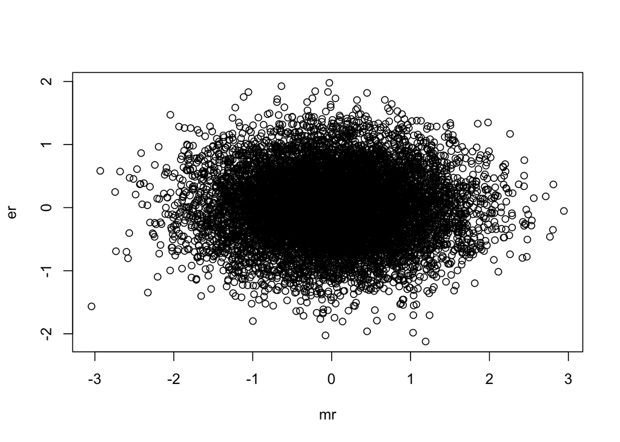

```r
mr <- lm(m ~ s1-1)$residuals
er <- lm(e ~ s1-1)$residuals

plot(mr, er)
```

```r
print(cor(mr, er))
```

```
## [1] -0.003426739
```

### Example where dimension of $\alpha$ is larger

```r
p <- 200
k <- 30

alpha <- rustiefel(p, k)
eps <- rnorm(p)
eps <- eps/sqrt(sum(eps^2))
beta <- (alpha %*% rustiefel(k, 1)) + eps
beta <- beta/sqrt(sum(beta^2))


library(mvtnorm)
library(rstiefel)

X <- rmvnorm(1e4, rep(0, p), diag(1, p))
m <- X %*% alpha
e <- X %*% beta

## projection matrices into the nullspaces of alpha and beta
A <- diag(p) - alpha %*% t(alpha)
B <- diag(p) - beta %*% t(beta)

## vectors in null space of alpha and beta
z <- eigen(A)$vectors[, 1:(p-k)]
w <- eigen(B - z %*% t(z))$vectors[, 1:(k-1)]

z <- eigen(A)$vectors[, 1:(p-k)] %*% rustiefel(p-k, 20)
w <- eigen(B - z %*% t(z))$vectors[, 1:(p-ncol(z)-1)]

## M is now a rank (p-1) projection matrix
M <- w %*% t(w) + z %*% t(z)

## verify zero condition holds
t(alpha) %*% M %*% beta
```

```
##                [,1]
##  [1,]  3.903128e-18
##  [2,]  2.634611e-17
##  [3,] -3.816392e-17
##  [4,]  4.366624e-17
##  [5,] -5.347827e-17
##  [6,]  3.659182e-17
##  [7,] -2.862294e-17
##  [8,] -4.003417e-17
##  [9,] -3.068292e-17
## [10,] -4.336809e-19
## [11,] -7.855045e-17
## [12,] -2.618348e-17
## [13,] -5.160802e-17
## [14,] -5.637851e-17
```

[output cut: 16 more lines]

```r
## gamma is now the eigenvector of I - M
eig <- eigen(diag(p) - M)
g <- eig$vectors[, 1]

# should be exactly one eigenvalue equal to 1 (rest are 0)
print(head(eig$values))
```

```
## [1] 1.000000e+00 1.126425e-14 8.362776e-15 6.653790e-15 5.558463e-15
## [6] 5.039902e-15
```

```r
## verify
s1 <- X %*% g

print(summary(cor(m, s1)))
```

```
##        V1
##  Min.   :-0.330061
##  1st Qu.:-0.116862
##  Median :-0.002422
##  Mean   :-0.024189
##  3rd Qu.: 0.043823
##  Max.   : 0.380792
```

```r
print(summary(cor(m, e)))
```

```
##        V1
##  Min.   :-0.319193
##  1st Qu.:-0.109418
##  Median :-0.001271
##  Mean   :-0.023425
##  3rd Qu.: 0.040904
##  Max.   : 0.367619
```

```r
print(cor(e, s1))
```

```
##           [,1]
## [1,] 0.9625962
```

```r
print(cor(lm(e ~ m-1)$fitted.values, e))
```

```
##           [,1]
## [1,] 0.7447394
```

```r
print(cor(lm(e ~ m-1)$fitted.values, s1))
```

```
##           [,1]
## [1,] 0.7738902
```

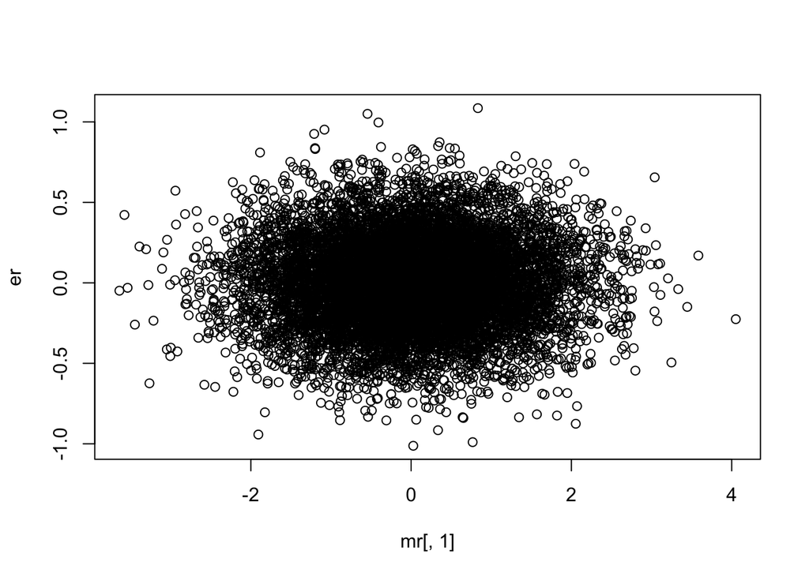

```r
mr <- lm(m ~ s1-1)$residuals
er <- lm(e ~ s1-1)$residuals

plot(mr[, 1], er)
```

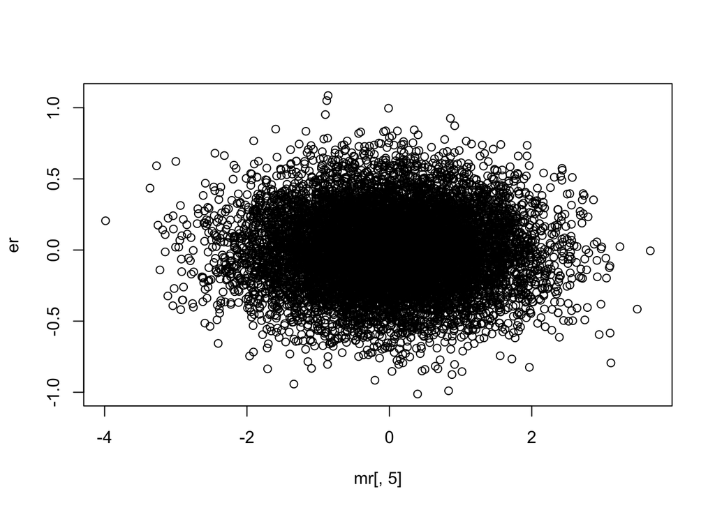

```r
plot(mr[, 5], er)
```

```r
print(summary(cor(mr, er)))
```

```
##        V1
##  Min.   :-0.0252317
##  1st Qu.:-0.0084461
##  Median : 0.0010618
##  Mean   :-0.0005165
##  3rd Qu.: 0.0057101
##  Max.   : 0.0180453
```